# Nitrogen impact on vegetation

Next, we need to derive scaling values from these bootstrap-lists (the columns) for every mapping unit in NiN. Here, we define things in the following way:

- Median = reference values
- 0.025 and 0.975 quantiles = lower and upper limit values
- min and max of the respective indicator’s scale = min/max values

```r
# every NiN-type is represented by one 'generalisert artsliste'
# some NiN-types are represented by two such species lists
# in some cases two NiN-types are represented by the same species list
#head(mountain.ref.cov[[1]])
mountain.ref.cov[[1]][0,]

# NiN-types where each type is represented by one species list (including when one species list represents two NiN-types), i.e. excluding types with a- and b-suffix
names(mountain.ref.cov[["Nitrogen"]])
x <- c(1:6,9:24,27)

# checking the actual NiN-types in the mountain lists
mountain.NiNtypes <- colnames(mountain.ref.cov[["Nitrogen"]])
mountain.NiNtypes[-x] <- substr(mountain.NiNtypes[-x], 1, nchar(mountain.NiNtypes[-x])-1)
mountain.NiNtypes

# 2 indicator-value indicators: Light, "Nitrogen"
indEll.n=2
# creating a table to hold:
# for every indicator: the 0.5 quantile (median), 0.025 quantile and  0.975 quantile for each NiN-type (3 metrics -> 3 columns per indicator), for Heat_requirement in alpine/arctic systems we do 0.05 quantile and  0.95 quantile and ignore the former as it is a one-sided indicator
# for every nature type (nrows)
tab <- matrix(ncol=3*indEll.n, nrow=25 ) # 25 basic ecosystem types
# coercing the values into the table

myQuantiles <- c(0.025, 0.5, 0.95) # the lowest quantile will not be used in this one-sided indicator

for (i in 1:length(x) ) {
  tab[i,1:3] <- quantile(as.matrix(mountain.ref.cov[["Light"]][,x[i]]),probs=myQuantiles,na.rm=T)
  tab[i,4:6] <- quantile(as.matrix(mountain.ref.cov[["Nitrogen"]][,x[i]]),probs=myQuantiles,na.rm=T)
}

tab <- as.data.frame(tab)
tab$NiN <- NA
tab$NiN[1:length(x)] <- names(mountain.ref.cov[[1]])[x]
tab


# NiN-types represented by several species lists
mountain.NiNtypes2 <- mountain.NiNtypes[-x]
unique(mountain.NiNtypes2)
grep(pattern=unique(mountain.NiNtypes2)[1], x=mountain.NiNtypes) # finds columns in e.g. colnames(mountain.ref.cov[["Light"]]) that match the first NiN-type


for (i in 1:length(unique(mountain.NiNtypes2)) ) {

  tab[length(x)+i,1:3] <- quantile(as.matrix(mountain.ref.cov[["Light"]][,grep(pattern=unique(mountain.NiNtypes2)[i], x=mountain.NiNtypes)]),probs=myQuantiles,na.rm=T)
  tab[length(x)+i,4:6] <- quantile(as.matrix(mountain.ref.cov[["Nitrogen"]][,grep(pattern=unique(mountain.NiNtypes2)[i], x=mountain.NiNtypes)]),probs=myQuantiles,na.rm=T)

  tab$NiN[length(x)+i] <- unique(mountain.NiNtypes2)[i]

}

tab

# when species lists represent several NiN-types
tab$NiN
tab <- rbind(tab,tab[c(3:6,18,20,23,25),])
tab$NiN[c(3:6,18,20,23,25,26:33)] <- c("T3-C3","T3-C9","T3-C2","T3-C8",
  "T7-C13","T7-C7","T22-C2","T22-C1",
  "T3-C6","T3-C12","T3-C5","T3-C11",                                                    "T7-C14","T7-C9","T22-C4","T22-C3"
 )
tab

# making it a proper data frame
dim(tab)
round(tab[,1:6],digits=2)

colnames(tab) <- c("Light_q2.5","Light_q50","Light_q97.5",
                   "Nitrogen_q2.5","Nitrogen_q50","Nitrogen_q97.5",

                   "NiN")
summary(tab)
tab$NiN <- gsub("C", "C-", tab$NiN) # add extra hyphen after C for NiN-types
tab


# restructuring into separate indicators for lower (q2.5) and higher (q97.5) than reference value (=median, q50)
y.Light <- numeric(length=nrow(tab)*2)
y.Light[((1:dim(tab)[1])*2)-1] <- tab$Light_q2.5
y.Light[((1:dim(tab)[1])*2)] <- tab$Light_q97.5

y.Nitrogen <- numeric(length=nrow(tab)*2)
y.Nitrogen[((1:dim(tab)[1])*2)-1] <- tab$Nitrogen_q2.5
y.Nitrogen[((1:dim(tab)[1])*2)] <- tab$Nitrogen_q97.5

# creating final objects holding the reference and limit values for all indicators

# ref object for indicators
mountain.ref.cov.val <- data.frame( grunn=c(rep(rep(tab$NiN,each=2),indEll.n)),
                                                    county=rep('all',(nrow(tab)*2*indEll.n)),
                                                    region=rep('all',(nrow(tab)*2*indEll.n)),
                                                    Ind=c(rep(c('Light1','Light2'),nrow(tab)),
                                                          rep(c('Nitrogen1','Nitrogen2'),nrow(tab))

                                                    ),
                                                    Rv=c(rep(tab$Light_q50,each=2),
                                                         rep(tab$Nitrogen_q50,each=2)
                                                    ),
                                                    Gv=c(y.Light,y.Nitrogen),
                                                    maxmin=c(rep(c(1,7),nrow(tab)), # 7 levels of Light
                                                             rep(c(1,9),nrow(tab))  # 9 levels of nitrogen
                                                    )
)

mountain.ref.cov.val
mountain.ref.cov.val$grunn <- as.factor(mountain.ref.cov.val$grunn)
mountain.ref.cov.val$Ind <- as.factor(mountain.ref.cov.val$Ind)
summary(mountain.ref.cov.val)
```

```r
mountain.ref.cov.val %>%
  kable(
    "html",
    caption = "Reference values (Rv and threshold values (Gv) for each indicator and nature type combination"
  ) %>%
  kable_styling("striped") %>%
  scroll_box(width = "100%", height = "300px")
```

Reference values (Rv and threshold values (Gv) for each indicator and nature type combination

| grunn | county | region | Ind | Rv | Gv | maxmin |
| --- | --- | --- | --- | --- | --- | --- |
| T14-C-1 | all | all | Light1 | 6.048096 | 5.595188 | 1 |
| T14-C-1 | all | all | Light2 | 6.048096 | 6.492440 | 7 |
| T14-C-2 | all | all | Light1 | 6.241595 | 5.695206 | 1 |
| T14-C-2 | all | all | Light2 | 6.241595 | 6.621879 | 7 |
| T3-C-3 | all | all | Light1 | 5.292181 | 4.838396 | 1 |
| T3-C-3 | all | all | Light2 | 5.292181 | 5.726245 | 7 |
| T3-C-9 | all | all | Light1 | 6.085840 | 5.841030 | 1 |
| T3-C-9 | all | all | Light2 | 6.085840 | 6.260437 | 7 |
| T3-C-2 | all | all | Light1 | 4.924128 | 4.691841 | 1 |
| T3-C-2 | all | all | Light2 | 4.924128 | 5.154226 | 7 |
| T3-C-8 | all | all | Light1 | 5.857503 | 5.634445 | 1 |
| T3-C-8 | all | all | Light2 | 5.857503 | 6.038154 | 7 |
| T3-C-4 | all | all | Light1 | 4.873677 | 4.602691 | 1 |
| T3-C-4 | all | all | Light2 | 4.873677 | 5.107569 | 7 |
| T3-C-7 | all | all | Light1 | 5.503418 | 5.330503 | 1 |
| T3-C-7 | all | all | Light2 | 5.503418 | 5.641432 | 7 |
| T3-C-10 | all | all | Light1 | 5.704967 | 5.512894 | 1 |
| T3-C-10 | all | all | Light2 | 5.704967 | 5.854290 | 7 |
| T3-C-13 | all | all | Light1 | 4.472559 | 4.177319 | 1 |
| T3-C-13 | all | all | Light2 | 4.472559 | 4.722868 | 7 |
| T3-C-14 | all | all | Light1 | 4.726491 | 4.495313 | 1 |
| T3-C-14 | all | all | Light2 | 4.726491 | 4.900315 | 7 |
| T7-C-1 | all | all | Light1 | 5.649462 | 5.017535 | 1 |
| T7-C-1 | all | all | Light2 | 5.649462 | 6.094483 | 7 |
| T7-C-2 | all | all | Light1 | 5.760598 | 5.397406 | 1 |
| T7-C-2 | all | all | Light2 | 5.760598 | 6.040095 | 7 |
| T7-C-3 | all | all | Light1 | 5.853582 | 5.554435 | 1 |
| T7-C-3 | all | all | Light2 | 5.853582 | 6.072665 | 7 |
| T7-C-6 | all | all | Light1 | 6.084302 | 5.854405 | 1 |
| T7-C-6 | all | all | Light2 | 6.084302 | 6.277099 | 7 |

[output cut: 102 more lines]

For scaling ANO-data against the reference we use the normalisation function from package ecTools.

```r
#### calculating scaled and non-truncated values for the indicators based on the dataset ####
# drop geometry
ANO.mountain <- ANO.mountain %>%
  mutate(
    X = st_coordinates(.)[, 1],
    Y = st_coordinates(.)[, 2]
  ) %>%
  st_drop_geometry()

ANO.mountain <- ANO.mountain |>
  mutate(
    kartleggingsenhet_1m2 = stringr::str_remove(kartleggingsenhet_1m2, "\\s.*$")
  )


for (i in 1:nrow(ANO.mountain) ) {  #
  tryCatch({
    #print(i)
    #print(paste(ANO.mountain$ano_flate_id[i]))
    #print(paste(ANO.mountain$ano_punkt_id[i]))
    #    ANO.mountain$Hovedoekosystem_sirkel[i]
    #    ANO.mountain$Hovedoekosystem_rute[i]



    # if the ANO.hovedtype exists in the mountain reference
    if ( ANO.mountain$hovedtype_rute[i] %in% unique(sub("\\-.*", "", mountain.ref.cov.val$grunn)) ) {

      # if there is any species present in current ANO point
      if ( length(ANO.sp.ind[ANO.sp.ind$parentglobalid==as.character(ANO.mountain$globalid[i]),'Species']) > 0 ) {


        # Nitrogen
        dat <- ANO.sp.ind[ANO.sp.ind$parentglobalid==as.character(ANO.mountain$globalid[i]),c('art_dekning','Nitrogen')]
        ANO.mountain[i,'richness'] <- nrow(dat)
        dat <- dat[!is.na(dat$Nitrogen),]

        if ( nrow(dat)>0 ) {

          val <- sum(dat[,'art_dekning'] * dat[,'Nitrogen'],na.rm=T) / sum(dat[,'art_dekning'],na.rm=T)
#          # lower part of distribution
#          ref <- mountain.ref.cov.val[mountain.ref.cov.val$Ind=='Nitrogen1' & mountain.ref.cov.val$grunn==as.character(ANO.mountain[i,"kartleggingsenhet_1m2"]),'Rv']
#          lim <- mountain.ref.cov.val[mountain.ref.cov.val$Ind=='Nitrogen1' & mountain.ref.cov.val$grunn==as.character(ANO.mountain[i,"kartleggingsenhet_1m2"]),'Gv']
#          maxmin <- mountain.ref.cov.val[mountain.ref.cov.val$Ind=='Nitrogen1' & mountain.ref.cov.val$grunn==as.character(ANO.mountain[i,"kartleggingsenhet_1m2"]),'maxmin']
#          # normalisation
#          ANO.mountain[i,'Nitrogen1'] <- ec_normalise(variable = val, x0 = maxmin, x60 = lim, x100 = ref, fun = "linear")

          # upper part of distribution
          ref <- mountain.ref.cov.val[mountain.ref.cov.val$Ind=='Nitrogen2' & mountain.ref.cov.val$grunn==as.character(ANO.mountain[i,"kartleggingsenhet_1m2"]),'Rv']
          lim <- mountain.ref.cov.val[mountain.ref.cov.val$Ind=='Nitrogen2' & mountain.ref.cov.val$grunn==as.character(ANO.mountain[i,"kartleggingsenhet_1m2"]),'Gv']
          maxmin <- mountain.ref.cov.val[mountain.ref.cov.val$Ind=='Nitrogen2' & mountain.ref.cov.val$grunn==as.character(ANO.mountain[i,"kartleggingsenhet_1m2"]),'maxmin']
          # normalisation
          ANO.mountain[i,'Nitrogen2'] <- ec_normalise(variable = val, x0 = maxmin, x60 = lim, x100 = ref, fun = "linear")

        }


      }

    }

  }, error = function(e) {
    invisible(NULL)
  })
}

# generate overall Nitrogen indicator
ANO.mountain$Nitrogen <- ANO.mountain$Nitrogen2

#ANO.mountain$Nitrogen1[ANO.mountain$Nitrogen1==1] <- NA
#ANO.mountain$Nitrogen2[ANO.mountain$Nitrogen2==1] <- NA

# add geometry again
ANO.mountain <- ANO.mountain %>%
  st_as_sf(coords = c("X", "Y"), crs = st_crs(ANO.geo))
```

```r
head(ANO.mountain) %>%
  kable(
    "html",
    caption = "ANO plots for ecosystems with scaled indicator values in the far-right columns."
  ) %>%
  kable_styling("striped") %>%
  scroll_box(width = "100%")
```

ANO plots for ecosystems with scaled indicator values in the far-right columns.

| globalid | registeringsdato | klokkeslett_start | ano_flate_id | ano_punkt_id | ssb_id | program | instruks | aar | dataansvarlig_mdir | dataeier | vaer | hovedoekosystem_250m2 | andel_hovedoekosystem_250m2 | utilgjengelig_punkt | utilgjengelig_begrunnelse | gps | noeyaktighet | kommentar_posisjon | klokkeslett_karplanter_start | karplanter_dekning | klokkeslett_karplanter_slutt | karplanter_feltsjikt | moser_dekning | torvmoser_dekning | lav_dekning | stroe_dekning | jord_grus_stein_berg_dekning | stubber_kvister_dekning | alger_fjell_dekning | … |
| --- | --- | --- | --- | --- | --- | --- | --- | --- | --- | --- | --- | --- | --- | --- | --- | --- | --- | --- | --- | --- | --- | --- | --- | --- | --- | --- | --- | --- | --- | --- |
| {736EFDFC-4033-4EF4-A628-7EDDFF70E3A8} | 2019-09-02 12:00:00 | 17:40 | ANO0010 | ANO0010_62 | 22135007017000 | ANO | https://nedlasting.miljodirektoratet.no/naturovervaking/ano_instruks.pdf | 2019 | Miljøovervåking og miljødata | Miljødirektoratet | sol | fjell | NA | NA | NA | NA | NA | NA | NA | 77 | NA | NA | 80 | 2 | 2 | 10 | 2 | NA | NA | … |
| {CF04FC84-F117-4810-9088-8D5E06A10A7D} | 2019-09-03 12:00:00 | 12:45 | ANO0010 | ANO0010_66 | 22135007017000 | ANO | https://nedlasting.miljodirektoratet.no/naturovervaking/ano_instruks.pdf | 2019 | Miljøovervåking og miljødata | Miljødirektoratet | nedbør,vind | fjell | NA | NA | NA | NA | NA | NA | NA | 86 | NA | NA | 70 | 0 | 0 | 2 | 5 | NA | NA | … |
| {D00C390A-F8CB-4F43-9E11-44F4E90D0B42} | 2019-09-03 12:00:00 | 11:54 | ANO0010 | ANO0010_64 | 22135007017000 | ANO | https://nedlasting.miljodirektoratet.no/naturovervaking/ano_instruks.pdf | 2019 | Miljøovervåking og miljødata | Miljødirektoratet | nedbør,vind | fjell | NA | NA | NA | NA | NA | NA | NA | 35 | NA | NA | 20 | 0 | 60 | 10 | 10 | NA | NA | … |
| {2115CE7C-2AFA-4502-A878-83E1AA949529} | 2019-09-03 12:00:00 | 11:19 | ANO0010 | ANO0010_55 | 22135007017000 | ANO | https://nedlasting.miljodirektoratet.no/naturovervaking/ano_instruks.pdf | 2019 | Miljøovervåking og miljødata | Miljødirektoratet | nedbør,vind | fjell | NA | NA | NA | NA | NA | NA | NA | 40 | NA | NA | 25 | 0 | 70 | 2 | 0 | NA | NA | … |
| {B5B730DD-8CCC-4931-A483-0F87D0FAA777} | 2019-09-03 12:00:00 | 13:43 | ANO0010 | ANO0010_44 | 22135007017000 | ANO | https://nedlasting.miljodirektoratet.no/naturovervaking/ano_instruks.pdf | 2019 | Miljøovervåking og miljødata | Miljødirektoratet | overskyet,opphold,vind | fjell | NA | NA | NA | NA | NA | NA | NA | 67 | NA | NA | 90 | 0 | 6 | 2 | 0 | NA | NA | … |
| {27A879FD-3DD3-48BB-A6D3-FBE440C7108A} | 2019-09-03 12:00:00 | 09:58 | ANO0010 | ANO0010_51 | 22135007017000 | ANO | https://nedlasting.miljodirektoratet.no/naturovervaking/ano_instruks.pdf | 2019 | Miljøovervåking og miljødata | Miljødirektoratet | overskyet,opphold | fjell | NA | NA | NA | NA | NA | NA | NA | 67 | NA | NA | 75 | 7 | 20 | 15 | 0 | NA | NA | … |

#### Calculating national and regional indices

We can calculate national and region-wise indicator values using a mixed-effects, zero-one inflated beta-regression analysis. Since the indicator values are on a scale from 0-1 the data per definition don’t follow a Gaussian distribution, hence the zero-one inflated beta-regression. Since the underlying monitoring data are spatially aggregated (several points per site), not all points are independent, hence the mixed-effects model. The uncertainty around the national and region indicator values is derived from the same statistical model. The national and regional estimates are computed separately.

```r
## Fit ordered beta regression null-model with a random effect
# Norway

nitrogen.no <- glmmTMB(
  Nitrogen ~ 1 + (1|ano_flate_id),
  data = ANO.mountain,
  family = ordbeta
)

summary(nitrogen.no)
```

```
 Family: ordbeta  ( logit )
Formula:          Nitrogen ~ 1 + (1 | ano_flate_id)
Data: ANO.mountain

      AIC       BIC    logLik -2*log(L)  df.resid
   4174.5    4206.8   -2082.2    4164.5      4743

Random effects:

Conditional model:
 Groups       Name        Variance Std.Dev.
 ano_flate_id (Intercept) 0.2985   0.5464
Number of obs: 4748, groups:  ano_flate_id, 479

Dispersion parameter for ordbeta family (): 5.83

Conditional model:
            Estimate Std. Error z value Pr(>|z|)
(Intercept)   1.3555     0.0469   28.91   <2e-16 ***
---
Signif. codes:  0 '***' 0.001 '**' 0.01 '*' 0.05 '.' 0.1 ' ' 1
```

```r
# regions
nitrogen.re <- glmmTMB(
  Nitrogen ~ 0 + region + (1|ano_flate_id),
  data = ANO.mountain,
  family = ordbeta
)

summary(nitrogen.re)
```

```
 Family: ordbeta  ( logit )
Formula:          Nitrogen ~ 0 + region + (1 | ano_flate_id)
Data: ANO.mountain

      AIC       BIC    logLik -2*log(L)  df.resid
   4170.9    4229.1   -2076.5    4152.9      4739

Random effects:

Conditional model:
 Groups       Name        Variance Std.Dev.
 ano_flate_id (Intercept) 0.2857   0.5345
Number of obs: 4748, groups:  ano_flate_id, 479

Dispersion parameter for ordbeta family (): 5.82

Conditional model:
                      Estimate Std. Error z value Pr(>|z|)
regionCentral.Norway   1.59496    0.10014  15.928  < 2e-16 ***
regionEastern.Norway   1.16879    0.08938  13.077  < 2e-16 ***
regionNorthern.Norway  1.34808    0.05641  23.898  < 2e-16 ***
regionSouthern.Norway  1.34077    0.17218   7.787 6.85e-15 ***
regionWestern.Norway   1.32745    0.10241  12.962  < 2e-16 ***
---
Signif. codes:  0 '***' 0.001 '**' 0.01 '*' 0.05 '.' 0.1 ' ' 1
```

## 10. Results

The model estimates and standard errors are on a logit scale, but we can calculate indicator values and confidence intervals (CI) by transforming back from logit to values between 0-1

```r
NO_FUNI_002_table <- tibble(
  Region = c(
    "Norway",
    "Central Norway",
    "Eastern Norway",
    "Northern Norway",
    "Southern Norway",
    "Western Norway"
  ),
  indicator_value = c(
    plogis(summary(nitrogen.no)$coef$cond[, 1]),
    plogis(summary(nitrogen.re)$coef$cond[, 1])
  ),
  CI_upper = c(
    plogis(
      summary(nitrogen.no)$coef$cond[, 1] +
        1.96 * summary(nitrogen.no)$coef$cond[, 2]
    ),
    plogis(
      summary(nitrogen.re)$coef$cond[, 1] +
        1.96 * summary(nitrogen.re)$coef$cond[, 2]
    )
  ),
  CI_lower = as.numeric(
    plogis(
      summary(nitrogen.no)$coef$cond[, 1] -
        1.96 * summary(nitrogen.no)$coef$cond[, 2]
    ),
    plogis(
      summary(nitrogen.re)$coef$cond[, 1] -
        1.96 * summary(nitrogen.re)$coef$cond[, 2]
    )
  )
)
NO_FUNI_002_table
```

```
# A tibble: 6 × 4
  Region          indicator_value CI_upper CI_lower
  <chr>                     <dbl>    <dbl>    <dbl>
1 Norway                    0.795    0.810    0.780
2 Central Norway            0.831    0.857    0.780
3 Eastern Norway            0.763    0.793    0.780
4 Northern Norway           0.794    0.811    0.780
5 Southern Norway           0.793    0.843    0.780
6 Western Norway            0.790    0.822    0.780
```

To express the results as a distribution, we need to simulate mean estimates based on the models’ intercept and associated standard error.

```r
## Norway
# Fixed-effect intercept and SE
b0 <- fixef(nitrogen.no)$cond["(Intercept)"]
se_b0 <- sqrt(vcov(nitrogen.no)$cond["(Intercept)", "(Intercept)"])

# draw estimates and backtransform from logit-scale
eta_draws_no <- rnorm(1000, mean = b0, sd = se_b0)
mu_draws_no  <- plogis(eta_draws_no)


## regions
b_re <- fixef(nitrogen.re)$cond
vc_re <- vcov(nitrogen.re)$cond

eta_draws_re <- MASS::mvrnorm(
  n = 1000,
  mu = b_re,
  Sigma = vc_re
)

mu_draws_re <- plogis(eta_draws_re)


# combining nitrogen_no_sim and nitrogen_re_sim
mu <- mu_draws_re |>
  as_tibble() |>
  add_column(Norway = mu_draws_no) |>
  pivot_longer(everything(), names_to = "region") |>
  mutate(region = case_when(
    region == "regionCentral.Norway" ~ "C",
    region == "regionEastern.Norway" ~ "E",
    region == "regionNorthern.Norway" ~ "N",
    region == "regionWestern.Norway" ~ "W",
    region == "regionSouthern.Norway" ~ "S",
    .default = region
  )) |>
    add_column(year = "2024")
```

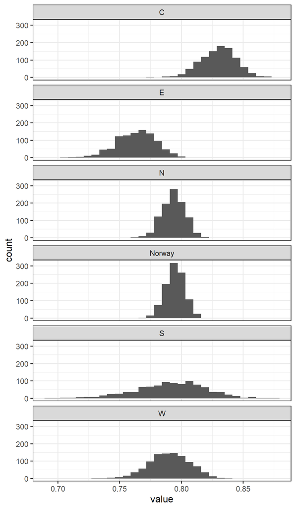

Figure 1: Histogram of indicator value distributions.

```r
mu |>
  ggplot(aes(x = value)) +
  geom_histogram() +
  facet_wrap(.~region, ncol=1) +
  theme_bw(base_size=16)
```

```r
mu |>
  group_by(region) |>
  summarise(
    'indicator value' = round(mean(value),2),
    low = round(quantile(value, probs = 0.025), 2),
    high = round(quantile(value, probs = .975), 2)
  ) |>
    unite(col = "95% CI", c(low, high), sep = " - ") |>
    gt::gt()
```

Table 2: Indicator values and 95% confidence intervals for NO_FUNI_002, calculated for Norwegian mountain ecosystems.

| region | indicator value | 95% CI |
| --- | --- | --- |
| C | 0.83 | 0.8 - 0.86 |
| E | 0.76 | 0.73 - 0.79 |
| N | 0.79 | 0.78 - 0.81 |
| Norway | 0.79 | 0.78 - 0.81 |
| S | 0.79 | 0.73 - 0.84 |
| W | 0.79 | 0.76 - 0.82 |

## 11. Export file

```r
arrow::write_parquet(mu, "data/results_NO_FUNI_002.parquet")
```

Demonstrating how to read back the data:

```r
arrow::read_parquet(here::here("data/results_NO_FUNI_002.parquet"))
```

```
# A tibble: 6,000 × 3
   region value year
   <chr>  <dbl> <chr>
 1 C      0.854 2024
 2 E      0.757 2024
 3 N      0.789 2024
 4 S      0.833 2024
 5 W      0.806 2024
 6 Norway 0.796 2024
 7 C      0.820 2024
 8 E      0.754 2024
 9 N      0.780 2024
10 S      0.780 2024
# ℹ 5,990 more rows
```

## 12. Author contributions

**CRediT statement**

- Conceptualization: [JT]
- Methodology: [JT]
- Data curation: [JT, ALK]
- Formal analysis: [JT]
- Investigation: [JT]

**MeRIT attribution**

This part supplements the CRediT statement with more granularity for method section.

**Study design** The study was designed by [JT].

**Data processing** Raw data were curated and cleaned by [JT and AK].

**Statistical analysis** All analyses were conducted by [JT] , with verification and minor edits by [AK].

**Visualization** Figures were produced by [AK].

**Reproducibility** All code was reviewed and validated by [AK].

**Session Info**

This workflow uses renv. Run `renv::restore()` to get started.